# Disaster Relief Project 2

Lauren O’Donnell (qsq6zz)

August 14, 2022

# 1 Introduction

## 1.1 Abstract

Following a 7.0 earthquake, Haiti was left devastated and many of its residents were left displaced from their home. Communication systems were down and roads were not in a usable state. In response, aerial images were taken to identify blue tarps, used as make-shift shelters by the displaced Haitians. This study was designed to develop an algorithm to best identify blue tarps from aerial images.

Algorithmic methods logistic regression, linear discriminant analysis, quadratic discriminant analysis, k-nearest neighbors, ridge regression, random forest, and support vector machines were used to develop models and algorithms to recognize blue tarps amid the devastated terrain of Haiti. Two models were generated, one with the features $Red$, $Green$, and $Blue$ from the pixel makeup and a second model for each method with the color features and an additional interaction effect between $Green$ and $Blue$ when predicting the response $Bluetarp$. Following analysis, many of the methods performed well in identifying blue tarps from aerial images. The best performing method with the training set was the support vector machines model containing no interaction effect while the best performing model with the holdout data was the logistic regression model containing the interaction effect. The overall best performing model, however, was a logistic regression model containing only features of $Red$, $Green$, and $Blue$ and no interaction effect. This model was selected due to its lesser complexity, decent performance with the smaller training set, and high performance with the holdout set, returning and accuracy of 99.866%. This model was also selected as the false negative rate was impressively low at 0.072%, which reduced the rate of missing a blue tarp and minimized the chances of mis-identifying a pixel in the image as having a blue tarp when it does not.

## 1.2 Data Introduction

Haiti was left devastated following a massive earthquake in 2010. Many Haitians were displaced from their destroyed homes, communication systems left unusable, and roads impassable. Displaced Haitians lived in makeshift shelters, using a blue tarp as a cover and easy identifier for deployed rescue workers to assist with recovery efforts. A team from the Rochester Institute of Technology took aerial photos of Haiti to identify the location of blue tarps and displaced Haitians. These aerial photographs were dissected pixel-by-pixel and analyzed to determine the Red-Green-Blue (RGB) makeup of the pixel and categorized into their appropriate class ($Blue Tarp$, $Rooftop$, $Soil$, $Various \ Non-Tarp$, or $Vegetation$).

This study is intended to determine an appropriate algorithm to identify a blue tarp based on the RGB combined quantities of the pixel. Algorithms will be analyzed and compared based on accuracy to ensure rescue workers can quickly and efficiently deliver supplies and assist displaced Haitians during the recovery.

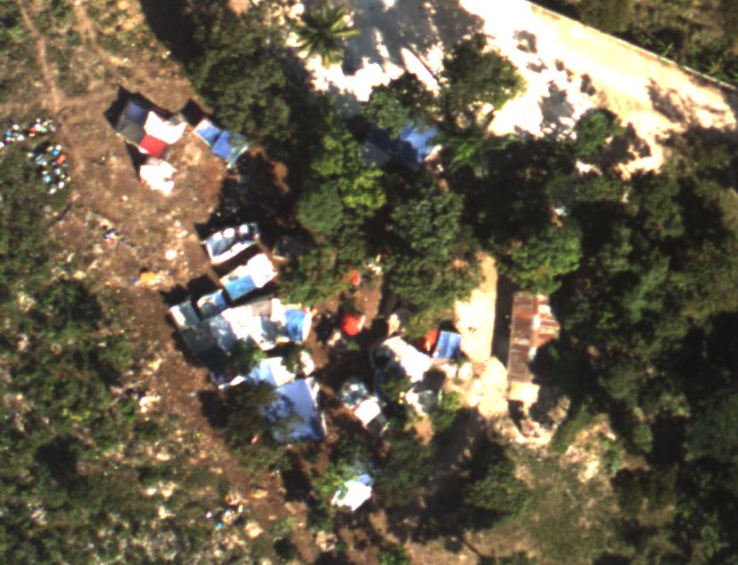

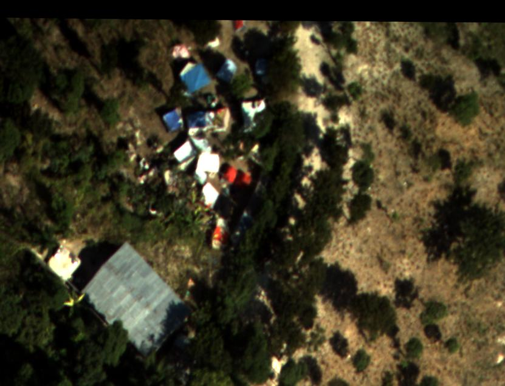

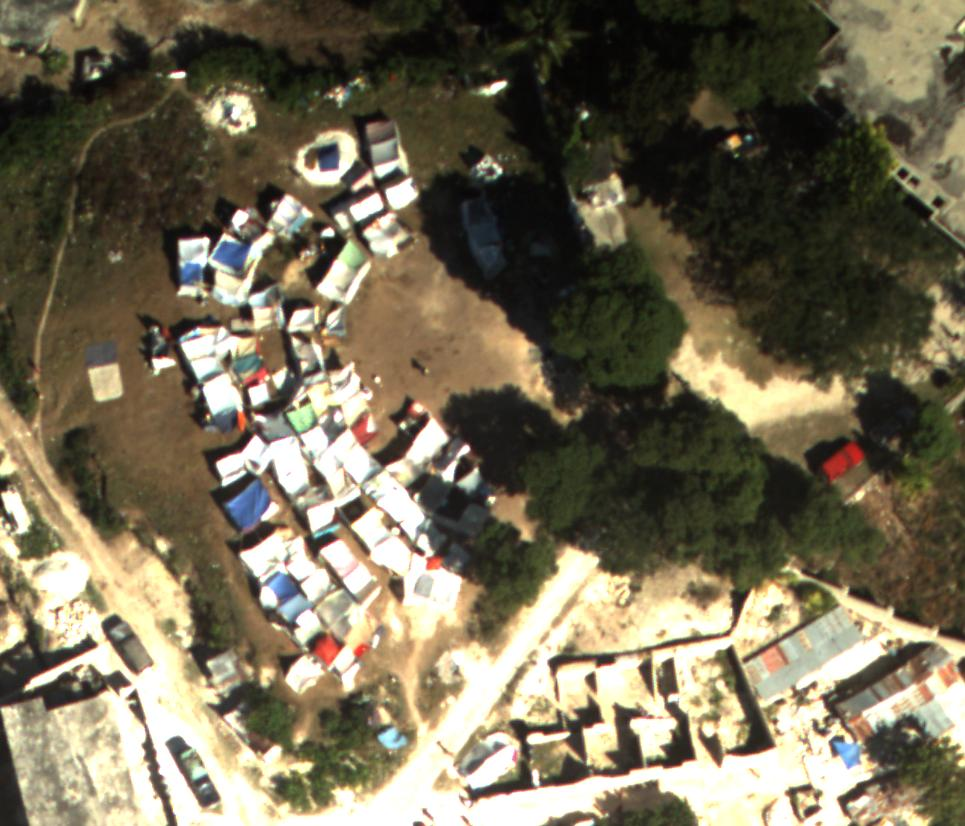

Haiti Makeshift Villages

```r
knitr::include_graphics(c("orthovnir071_makeshift_villiage1.jpg",
                   "orthovnir071_makeshift_villiage2.jpg",
                   "orthovnir078_makeshift_villiage1.jpg"))
```

# 2 Data Wrangling & Exploratory Data Analysis

## 2.1 Data Wrangling

Little wrangling was required on the training data set. All observations were complete with no missing values. To prepare the data set for analysis, new factor variable $Bluetarp$ was created by mutating `Data$Class` and classifying all observations identified as “Blue Tarp” as “Yes” and all other observations as “No”. The $Bluetarp$ variable was then converted to a factor and the $Class$ was dropped from the data set and the data set was names `Train`.

```r
# required libraries
library(tidyverse)
library(MASS)
library(caret)
library(GGally)
library(kableExtra)
library(leaps)
library(ROCR)
library(gridExtra)
library(knitr)
library(broom)
library(tictoc)
library(randomForest)
library(tree)

# Determine number of cores and initialize cluster
library(parallel)
library(doParallel)
no_cores <- detectCores() - 2
cl <- makePSOCKcluster(no_cores)
registerDoParallel(cl)
```

```r
# importing training set
Data <- read.csv("HaitiPixels.csv", header = TRUE)

# importing holdout sets
data057.nottarp <- read.csv("orthovnir057_ROI_NON_Blue_Tarps.txt",
                            header = FALSE, skip = 8, sep = "")
data067.tarp <- read.csv("orthovnir067_ROI_Blue_Tarps_data.txt",
                            header = FALSE, skip = 1, sep = "")
data067.tarp2 <- read.csv("orthovnir067_ROI_Blue_Tarps.txt",
                            header = FALSE, skip = 8, sep = "")
data067.nottarp <- read.csv("orthovnir067_ROI_NOT_Blue_Tarps.txt",
                            header = FALSE, skip = 8, sep = "")
data069.tarp <- read.csv("orthovnir069_ROI_Blue_Tarps.txt",
                         header = FALSE, skip = 8, sep = "")
data069.nottarp <- read.csv("orthovnir069_ROI_NOT_Blue_Tarps.txt",
                            header = FALSE, skip = 8, sep = "")
data078.tarp <- read.csv("orthovnir078_ROI_Blue_Tarps.txt",
                            header = FALSE, skip = 8, sep = "")
data078.nottarp <- read.csv("orthovnir078_ROI_NON_Blue_Tarps.txt",
                            header = FALSE, skip = 8, sep = "")
```

```r
# creating new binary variable that is acknowledging either a blue tarp or not
Data <- Data %>%
  mutate(Bluetarp = ifelse(Data$Class == "Blue Tarp", "Yes", "No"))

# converting Bluetarp to factor
Data$Bluetarp <- as.factor(Data$Bluetarp)

# dropping unnecessary Class feature
Train <- Data[,c(2:5)]
```

```r
# dropping unnecessary columns
# no changes to data067.tarp - no columns to drop
data057.nottarp <- data057.nottarp[,c(8:10)]
data067.tarp2 <- data067.tarp2[,c(8:10)]
data067.nottarp <- data067.nottarp[,c(8:10)]
data069.tarp <- data069.tarp[,c(8:10)]
data069.nottarp <- data069.nottarp[,c(8:10)]
data078.tarp <- data078.tarp[,c(8:10)]
data078.nottarp <- data078.nottarp[,c(8:10)]

# renaming columns
colnames = c("Red" = "V8", "Green" = "V9", "Blue" = "V10")

data057.nottarp <- data057.nottarp %>%
  rename(colnames)
data067.tarp <- data067.tarp %>%
  rename(c("Red" = "V1", "Green" = "V2", "Blue" = "V3"))
data067.tarp2 <- data067.tarp2 %>%
  rename(colnames)
data067.nottarp <- data067.nottarp %>%
  rename(colnames)
data069.tarp <- data069.tarp %>%
  rename(colnames)
data069.nottarp <- data069.nottarp %>%
  rename(colnames)
data078.tarp <- data078.tarp %>%
  rename(colnames)
data078.nottarp <- data078.nottarp %>%
  rename(colnames)

# adding factor column identifying tarp or not
data057.nottarp <- data057.nottarp %>%
  mutate(Bluetarp = "No")
data057.nottarp$Bluetarp <- as.factor(data057.nottarp$Bluetarp)

data067.tarp <- data067.tarp %>%
  mutate(Bluetarp = "Yes")
data067.tarp$Bluetarp <- as.factor(data067.tarp$Bluetarp)

data067.tarp2 <- data067.tarp2 %>%
  mutate(Bluetarp = "Yes")
data067.tarp2$Bluetarp <- as.factor(data067.tarp2$Bluetarp)

data067.nottarp <- data067.nottarp %>%
  mutate(Bluetarp = "No")
data067.nottarp$Bluetarp <- as.factor(data067.nottarp$Bluetarp)

data069.tarp <- data069.tarp %>%
  mutate(Bluetarp = "Yes")
data069.tarp$Bluetarp <- as.factor(data069.tarp$Bluetarp)

data069.nottarp <- data069.nottarp %>%
  mutate(Bluetarp = "No")
data069.nottarp$Bluetarp <- as.factor(data069.nottarp$Bluetarp)

data078.tarp <- data078.tarp %>%
  mutate(Bluetarp = "Yes")
data078.tarp$Bluetarp <- as.factor(data078.tarp$Bluetarp)

data078.nottarp <- data078.nottarp %>%
  mutate(Bluetarp = "No")
data078.nottarp$Bluetarp <- as.factor(data078.nottarp$Bluetarp)
```

```r
Holdout <- bind_rows(data057.nottarp, data067.tarp, data067.tarp2,
                     data067.nottarp, data069.tarp, data069.nottarp,
                     data078.tarp, data078.nottarp)
Holdout$Bluetarp <- relevel(Holdout$Bluetarp, "No")
```

```r
# used for testing code only - this will not be used for actual performance
set.seed(1)
Sample <- Holdout %>%
  sample_frac(0.1)
```

## 2.2 Exploratory Data Analysis

Exploratory data analysis (EDA) was conducted on both the training and holdout data sets. The training set was first evaluated to explore the data, find relationships, and help provide direction on which model(s) would be best fit to predict blue tarps from aerial images during disaster relief efforts. Following training set EDA, EDA was conducted on the holdout set to determine if there were similarities or differences between the two data sets.  
To prepare for EDA, several functions were generated to streamline visualizations and analysis.

```r
table.classes <- function(data, title) {
  data %>%
    dplyr::count(Class) %>%
    knitr::kable(caption = "Count of Various Classes",
                 col.names = c("Class", "Count")) %>%
    kableExtra::kable_styling(full_width = FALSE) %>%
    kable_styling(latex_options = "HOLD_position")
}

table.tarps <- function(data, title) {
  data %>%
    dplyr::count(Bluetarp) %>%
    knitr::kable(caption = title,
                 col.names = c("Blue Tarp", "Count")) %>%
    kableExtra::kable_styling(full_width = FALSE) %>%
    kable_styling(latex_options = "HOLD_position")
}
```

```r
pairsplot <- function(data) {
  data %>%
  ggpairs(aes(alpha = 0.01, color = Bluetarp),
          lower = list(combo = wrap("facethist", binwidth = 0.5))) +
  theme(axis.text.x = element_text(angle = 90, hjust = 1))
}
```

```r
all.densities <- function(data, title) {
  ggplot(data) +
    geom_density(aes(x = Red, color = "Red")) +
    geom_density(aes(x = Green, color = "Green")) +
    geom_density(aes(x = Blue, color = "Blue")) +
    labs(x = "RGB Density", title = title) +
    theme(plot.title = element_text(hjust = 0.5)) +
    scale_color_manual(values = c('Red' = 'Red',
                                  'Green' = 'Dark Green',
                                  "Blue" = "Blue"))
}

tarp.densities <- function(data, title) {
  ggplot(subset(data, Bluetarp == 'Yes')) +
    geom_density(aes(x = Red, color = "Red")) +
    geom_density(aes(x = Green, color = "Green")) +
    geom_density(aes(x = Blue, color = "Blue")) +
    labs(x = "RGB Density", title = title) +
    theme(plot.title = element_text(hjust = 0.5)) +
    scale_color_manual(values = c('Red' = 'Red',
                                  'Green' = 'Dark Green',
                                  "Blue" = "Blue"))
}
```

### 2.2.1 Training Set EDA

To begin EDA on the training data, tables were first created to display the frequency counts of each of the categories. The tables below made it clear there are far more pixels that do not contain a blue tarp as compared to those with a blue tarp.

```r
table.classes(Data, "Count of Various Classes: Training Set")
```

Count of Various Classes

| Class | Count |
| --- | --- |
| Blue Tarp | 2022 |
| Rooftop | 9903 |
| Soil | 20566 |
| Various Non-Tarp | 4744 |
| Vegetation | 26006 |

```r
table.tarps(Data, "Count of Blue Tarps: Training Set")
```

Count of Blue Tarps: Training Set

| Blue Tarp | Count |
| --- | --- |
| No | 61219 |
| Yes | 2022 |

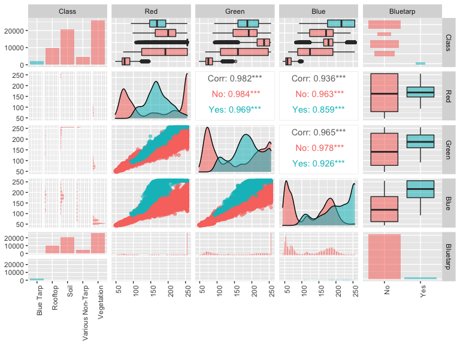

Variable Relationships: Training Data

```r
pairsplot(Data)
```

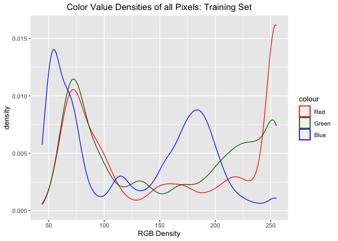

Color Value Densities: Training Data

```r
all.densities(Data, "Color Value Densities of all Pixels: Training Set")
```

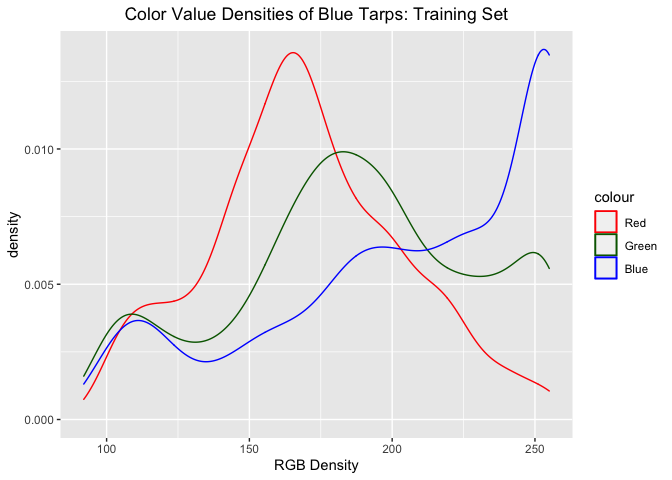

Color Value Densities of Blue Tarps: Training Set

```r
tarp.densities(Data, "Color Value Densities of Blue Tarps: Training Set")
```

The `ggpairs()` plot, Figure 2, revealed what appeared to be positive linear relationships between each of the quantitative RGB values based on the scatter plots. The density plots on Figure 2 showed a generally similar shape in densities for the $Red$ and $Green$ variables where there was a high density around 70 with a sharp decrease in density until around 200 where both started to increase.

The box plots revealed what appeared to be little significance between the $Bluetarp$ variable and $Red$ as the means were very similar. The spread was also much greater for non-blue tarp pixels than pixels identified as a blue tarp; though, interestingly, the maximums are approximately the same. $Blue$ pixels appear to have the strongest relationship with $Bluetarp$s, as expected, seen by the greatest change in means from pixels with and without a blue tarp. $Green$ pixels appeared to have a similar, though not as strong as $Blue$, correlation with $Bluetarp$ identified pixels. This may be because visually blue and green appear similar to the human eye.

Figure 4 displays the density of the colors when the pixel contains a blue tarp. This reveals that the highest density of pixels that do have a blue tarp have a very high number (color density) of $Blue$ and tend to have lower color density values of $Red$ and $Green$. This aligns with what was observed with the `ggpairs()` plot as there tends to be a higher value of $Green$ than $Red$ when there is a blue tarp.

### 2.2.2 Holdout Set EDA

EDA was then conducted on the holdout set to determine if the training set is a good representative sample of the full data set. Because data was not provided on the class, EDA on the holdout set began with the table of counts of blue tarp pixels versus non-blue tarp pixels.

```r
table.tarps(Holdout, "Count of Blue Tarps: Holdout Set")
```

Count of Blue Tarps: Holdout Set

| Blue Tarp | Count |
| --- | --- |
| No | 1989697 |
| Yes | 18926 |

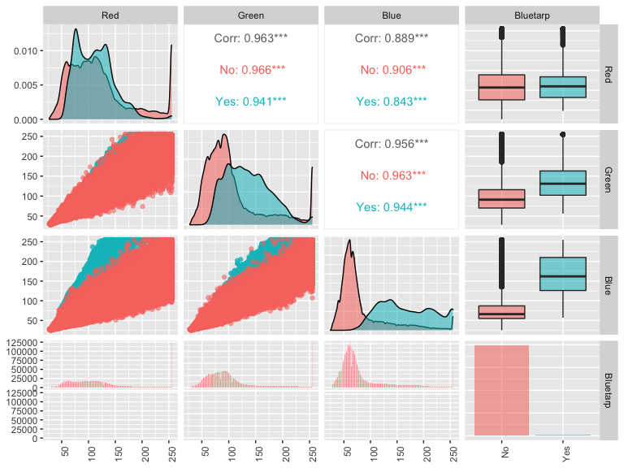

Variable Relationships: Holdout Data

```r
pairsplot(Holdout)
```

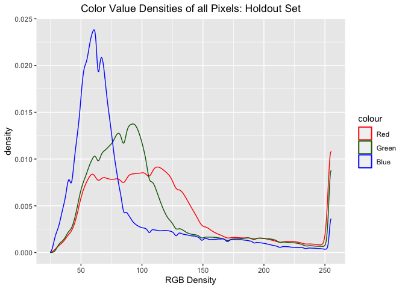

Color Value Densities: Holdout Data

```r
all.densities(Holdout, "Color Value Densities of all Pixels: Holdout Set")
```

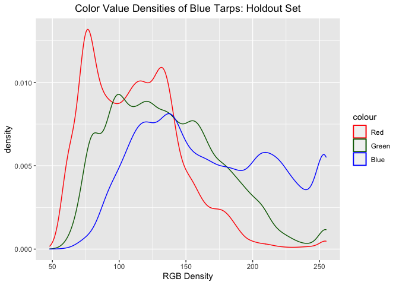

Color Value Densities of Blue Tarps: Holdout Set

```r
tarp.densities(Holdout, "Color Value Densities of Blue Tarps: Holdout Set")
```

Overall, the training and holdout data sets did vary in some key areas. The first observed difference was in the distribution of blue tarps in the overall data set. The training set contains 2022 total blue tarps, equating to 3.197% of the total data points in the training set. In contrast, the holdout set only contains 18,926 blue tarps, translating to 0.942%. This large difference could indicate the training set is not representative of the data set as a whole impacting the models performance when the holdout set is tested.

When comparing the `ggpairs()` plots, the differences in the density plots stood out. All three of the density plots presented different distributions of each of the colors for both blue tarp and non-blue tarp pixels. The most dramatic difference was observed with the densities of the $Blue$ variable. This is likely due to the extremely small number of confirmed blue tarps in the holdout data set. The other color variables were also flatter than that of the training set, but the difference was not as dramatic as $Blue$. Other comparisons included in the `ggpairs()` plots were not as different, including the correlation values.

# 3 Variable Selection

Variable selection techniques were run before model training to determine the best variables for the model. Adjusted $R^2$, Mallow’s $C_p$, and $BIC$ were first used to investigate the appropriate model followed by forward, backward, and stepwise selection. As the $Class$ variable was used directly to create the $Bluetarp$ response, $Class$ was not included in any of the models.

```r
regfit <- regsubsets(Bluetarp ~ ., data = Train)
reg.summary <- summary(regfit)
reg.summary
```

```
#> Subset selection object
#> Call: regsubsets.formula(Bluetarp ~ ., data = Train)
#> 3 Variables  (and intercept)
#>       Forced in Forced out
#> Red       FALSE      FALSE
#> Green     FALSE      FALSE
#> Blue      FALSE      FALSE
#> 1 subsets of each size up to 3
#> Selection Algorithm: exhaustive
#>          Red Green Blue
#> 1  ( 1 ) " " " "   "*"
#> 2  ( 1 ) "*" " "   "*"
#> 3  ( 1 ) "*" "*"   "*"
```

```r
R2CPBIC <- function(reg) {
  regfit <- regsubsets(reg, data = Train)
  reg.summary <- summary(regfit)

  reg.summary <- regfit %>%
    tidy()

  RSSs <- tibble(RSS = regfit$rss) %>%
  ggplot(aes(x = seq_along(RSS), y = RSS)) +
  geom_line() +
  xlab("Number of Variables")

  adjR2s <- reg.summary %>%
    ggplot(aes(x = seq_along(adj.r.squared), y = adj.r.squared)) +
    geom_line() +
    geom_point(reg.summary, color = 'red', size = 2.5,
             mapping = aes(x = which.max(adj.r.squared),
                           y = max(adj.r.squared))) +
    xlab("Number of Variables")

  mallows_cps <- reg.summary %>%
    ggplot(aes(x = seq_along(mallows_cp), y = mallows_cp)) +
    geom_line() +
    geom_point(reg.summary, color = 'red', size = 2.5,
             mapping = aes(x = which.min(mallows_cp), y = min(mallows_cp))) +
    xlab("Number of Variables")

  BICs <- reg.summary %>%
    ggplot(aes(x = seq_along(BIC), y = BIC)) + geom_line() +
    geom_point(reg.summary, color = 'red', size = 2.5,
             mapping = aes(x = which.min(BIC), y = min(BIC))) +
    xlab("Number of Variables")

  grid.arrange(RSSs, adjR2s, mallows_cps, BICs, nrow = 2)

  return(regfit)
}
```

```r
R2CPBIC.var <- function (regfit) {
  par(mfrow = c(1, 1))

  plot(regfit, scale = "r2")
  plot(regfit, scale = "adjr2")
  plot(regfit, scale = "Cp")
  plot(regfit, scale = "bic")

}
```

```r
colors <- R2CPBIC(Bluetarp ~ .)
```

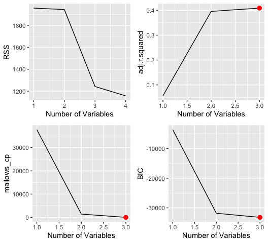

Standard Model Selection: RSS, Adjusted R2, Mallow’s Cp, and BIC

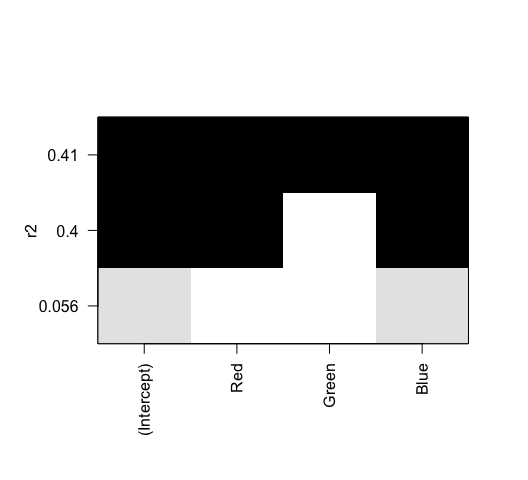

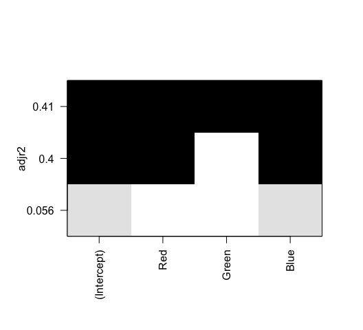

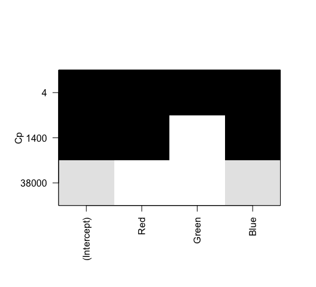

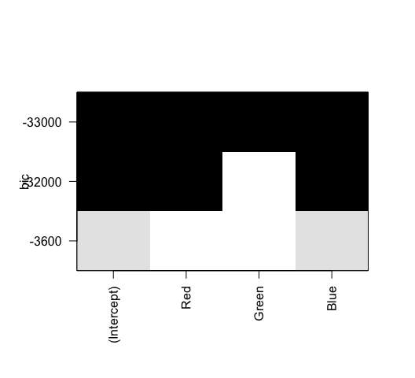

Standard Model Variable Selection: RSS, Adjusted R2, Mallow’s Cp, and BIC

```r
R2CPBIC.var(colors)
```

```r
modelselection <- function(reg, direction) {
  set.seed(1)
  regfit <- train(reg, data = Train,
                         trControl = trainControl(method = "none",
                                                  allowParallel = TRUE),
                         method = "glmStepAIC", direction = direction)
  return(regfit)
}
```

```r
regfit.fwd <- modelselection(Bluetarp ~ ., 'forward')
```

```
#> Start:  AIC=17903.6
#> .outcome ~ 1
#>
#>         Df Deviance   AIC
#> + Blue   1    13619 13623
#> + Green  1    17470 17474
#> + Red    1    17887 17891
#> <none>        17902 17904
#>
#> Step:  AIC=13623.11
#> .outcome ~ Blue
#>
#>         Df Deviance     AIC
#> + Red    1   2065.5  2071.5
#> + Green  1   3007.1  3013.1
#> <none>      13619.1 13623.1
#>
#> Step:  AIC=2071.49
#> .outcome ~ Blue + Red
#>
#>         Df Deviance    AIC
#> + Green  1   1769.5 1777.5
#> <none>       2065.5 2071.5
#>
#> Step:  AIC=1777.53
#> .outcome ~ Blue + Red + Green
```

```r
regfit.bwd <- modelselection(Bluetarp ~ ., 'backward')
```

```
#> Start:  AIC=1777.53
#> .outcome ~ Red + Green + Blue
#>
#>         Df Deviance    AIC
#> <none>       1769.5 1777.5
#> - Green  1   2065.5 2071.5
#> - Red    1   3007.1 3013.1
#> - Blue   1   8313.1 8319.1
```

```r
regfit.step <- modelselection(Bluetarp ~ ., 'both')
```

```
#> Start:  AIC=1777.53
#> .outcome ~ Red + Green + Blue
#>
#>         Df Deviance    AIC
#> <none>       1769.5 1777.5
#> - Green  1   2065.5 2071.5
#> - Red    1   3007.1 3013.1
#> - Blue   1   8313.1 8319.1
```

```r
regfit2 <- regsubsets(Bluetarp ~ . + Green:Blue, data = Train)
```

```r
interaction <- R2CPBIC(Bluetarp ~ . + Green:Blue)
```

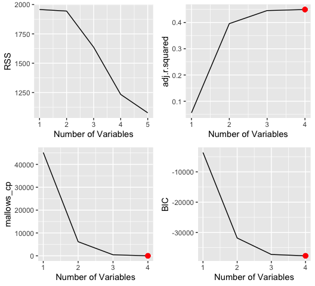

Interaction Model Selection: RSS, Adjusted R2, Mallow’s Cp, and BIC

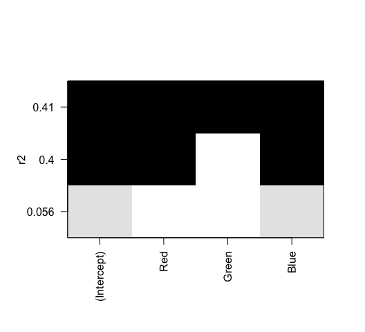

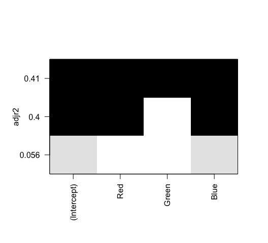

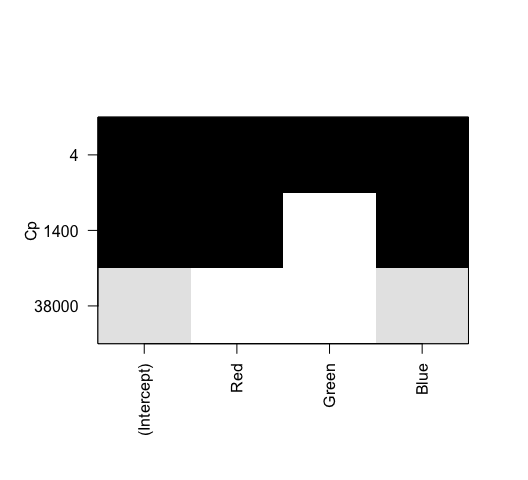

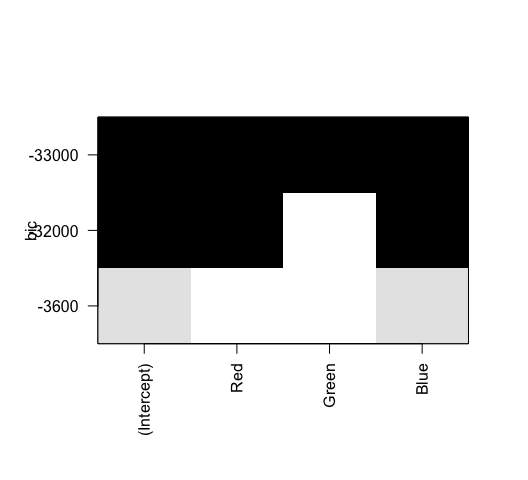

```r
R2CPBIC.var(colors)
```

```r
regfit.i.fwd <- modelselection(Bluetarp ~ . + Green:Blue, 'forward')
```

```
#> Start:  AIC=17903.6
#> .outcome ~ 1
#>
#>         Df Deviance   AIC
#> + Blue   1    13619 13623
#> + Green  1    17470 17474
#> + Red    1    17887 17891
#> <none>        17902 17904
#>
#> Step:  AIC=13623.11
#> .outcome ~ Blue
#>
#>         Df Deviance     AIC
#> + Red    1   2065.5  2071.5
#> + Green  1   3007.1  3013.1
#> <none>      13619.1 13623.1
#>
#> Step:  AIC=2071.49
#> .outcome ~ Blue + Red
#>
#>         Df Deviance    AIC
#> + Green  1   1769.5 1777.5
#> <none>       2065.5 2071.5
#>
#> Step:  AIC=1777.53
#> .outcome ~ Blue + Red + Green
#>
#>              Df Deviance    AIC
#> + Green:Blue  1   1388.0 1398.0
#> <none>            1769.5 1777.5
#>
#> Step:  AIC=1398.01
#> .outcome ~ Blue + Red + Green + Blue:Green
```

```r
regfit.i.bwd <- modelselection(Bluetarp ~ . + Green:Blue, 'backward')
```

```
#> Start:  AIC=1398.01
#> .outcome ~ Red + Green + Blue + `Green:Blue`
#>
#>                Df Deviance    AIC
#> <none>              1388.0 1398.0
#> - Green         1   1473.1 1481.1
#> - `Green:Blue`  1   1769.5 1777.5
#> - Red           1   2727.4 2735.4
#> - Blue          1   7384.6 7392.6
```

```r
regfit.i.step <- modelselection(Bluetarp ~ . + Green:Blue, 'both')
```

```
#> Start:  AIC=1398.01
#> .outcome ~ Red + Green + Blue + `Green:Blue`
#>
#>                Df Deviance    AIC
#> <none>              1388.0 1398.0
#> - Green         1   1473.1 1481.1
#> - `Green:Blue`  1   1769.5 1777.5
#> - Red           1   2727.4 2735.4
#> - Blue          1   7384.6 7392.6
```

Results from the three-variable model selection procedures (referred to as the “standard model”) revealed all three color predictors should be included in the final model. When the same tests were run adding an interaction effect between $Green$ and $Blue$, all model selection procedures recommended a four variable model including the interaction effect.  
Models were created using both three and four variables to compare model predictive performance between models and regression creation techniques and determine the best model to identify blue tarps in the event of another disaster throughout the course of this study.

# 4 Model Fitting, Tuning Parameter Selection, and Evaluation

## 4.1 Preparations

Due to the size of the data set, K-Fold Cross Validation was used to cross-validate the data. The function below was prepared using $k = 10$ folds to maximize the amount of training conducted on the data set. Functions were also prepared to determine the threshold and generate a confusion matrix, ROC Curve and calculate the AUC for both the training and holdout data sets.

Folds were set to standardize the set of data and folds across all models for the probability thresholds function `threshold`.

```r
# general model training function
set.seed(1) # setting seed for consistency across all splits and models

split <- createDataPartition(Train$Bluetarp, times = 10)

trmethod <- trainControl(method = 'cv',
                         index = split,
                         savePredictions = TRUE,
                         classProbs = TRUE,
                         allowParallel = TRUE)

model <- function(reg, method, tuneGrid, ...) {
  model <- train(reg, data = Train,
                 method = method,
                 tuneGrid = tuneGrid,
                 trControl = trmethod)
  return(model)
}
```

```r
# threshold function
folds <- createFolds(Train$Bluetarp, k = 10, list = TRUE, returnTrain = TRUE)

control <- trainControl(method = "cv",
                        number = 10,
                        index = folds,
                        savePredictions = TRUE,
                        classProbs = TRUE,
                        allowParallel = TRUE,
                        returnResamp = 'all')

thres <- seq(0.05,0.90, by = 0.05)

threshold <- function(model) {
  set.seed(1)
  stats <- thresholder(model,
                       threshold = thres,
                       statistics = 'all')
  # creating FNR and FPR values to return to threshold variables
  stats$FNR <- 1 - stats$Sensitivity
  stats$FPR <- 1 - stats$Specificity

  return(stats)
}
```

```r
# ROC curve and AUC function
ROC <- function(model, title, threshold) {
  probsTest <- predict(model, Train, type = "prob")
  preds <- factor(ifelse(probsTest[, "Yes"] > max(threshold$Accuracy),
                            "Yes", "No") )
  # preds <- relevel(preds, "Yes")

  # confusion matrix
  print(confusionMatrix(preds, Train$Bluetarp))

  # ROC
  rates <- prediction(probsTest$Yes, Train$Bluetarp,
                      label.ordering = c('No', 'Yes'))
  model.roc <- performance(rates, measure = 'tpr', x.measure = 'fpr')
  plot(model.roc, colorize = T,
       print.cutoffs.at = c(0, min(threshold$Dist), 1.0))
  lines(x = c(0,1), y = c(0,1), col = 'grey')
  title(main = title)

  auc <- performance(rates, measure = "auc")
  auc.val <- auc@y.values[[1]]
  return(auc.val)
}
```

```r
cm <- function(model, threshold) {
  probsTest <- predict(model, Holdout, type = "prob")
  preds <- factor(ifelse(probsTest[, "Yes"] > max(threshold$Accuracy),
                            "Yes", "No") )

  matrix <- confusionMatrix(preds, Holdout$Bluetarp)

  # creating FNR and FPR values to return to threshold variables
  matrix$FNR <- 1 - matrix$byClass['Sensitivity']
  matrix$FPR <- 1 - matrix$byClass['Specificity']
  return(matrix)
}
```

```r
holdoutperf <- function(model, title, threshold) {
  probsTest <- predict(model, Holdout, type = "prob")

  # ROC
  rates <- prediction(probsTest$Yes, Holdout$Bluetarp,
                      label.ordering = c('No', 'Yes'))
  model.roc <- performance(rates, measure = 'tpr', x.measure = 'fpr')
  plot(model.roc, colorize = T,
       print.cutoffs.at = c(0, max(threshold$Accuracy), 1.0))
  lines(x = c(0,1), y = c(0,1), col = 'grey')
  title(main = title)

  # AUC
  auc <- performance(rates, measure = "auc")
  auc.val <- auc@y.values[[1]]
  return(auc.val)
}
```

## 4.2 Logistic Regression

### 4.2.1 Model Training

Logistic regression was the first model approach tested. Models were generated by calling the `model` function and passing `glm` and additional attribute `family = binomial` into the function. The standard three-variable model consisting of only the three color features was generated as well as an interaction model with four variables that included the interaction effect between $Green$ and $Blue$.

```r
lr.fit <- model(Bluetarp ~ ., 'glm', NULL,
                family = 'binomial', metric = "Accuracy")
summary(lr.fit)
```

```
#>
#> Call:
#> NULL
#>
#> Deviance Residuals:
#>     Min       1Q   Median       3Q      Max
#> -3.4266  -0.0205  -0.0015   0.0000   3.7911
#>
#> Coefficients:
#>             Estimate Std. Error z value Pr(>|z|)
#> (Intercept)  0.20984    0.18455   1.137    0.256
#> Red         -0.26031    0.01262 -20.632   <2e-16 ***
#> Green       -0.21831    0.01330 -16.416   <2e-16 ***
#> Blue         0.47241    0.01548  30.511   <2e-16 ***
#> ---
#> Signif. codes:  0 '***' 0.001 '**' 0.01 '*' 0.05 '.' 0.1 ' ' 1
#>
#> (Dispersion parameter for binomial family taken to be 1)
#>
#>     Null deviance: 17901.6  on 63240  degrees of freedom
#> Residual deviance:  1769.5  on 63237  degrees of freedom
#> AIC: 1777.5
#>
#> Number of Fisher Scoring iterations: 12
```

```r
lr.fit$results
```

```
#>   parameter  Accuracy     Kappa   AccuracySD     KappaSD
#> 1      none 0.9952941 0.9209137 0.0002962241 0.005261208
```

```r
lr.fit.i <- model(Bluetarp ~ . + Green:Blue, 'glm', NULL,
                  family = 'binomial')
summary(lr.fit.i)
```

```
#>
#> Call:
#> NULL
#>
#> Deviance Residuals:
#>     Min       1Q   Median       3Q      Max
#> -3.5173  -0.0242  -0.0061   0.0000   3.0984
#>
#> Coefficients:
#>                Estimate Std. Error z value Pr(>|z|)
#> (Intercept)  -8.272e+00  5.487e-01 -15.077   <2e-16 ***
#> Red          -2.208e-01  1.039e-02 -21.248   <2e-16 ***
#> Green        -1.050e-01  1.179e-02  -8.903   <2e-16 ***
#> Blue          4.469e-01  1.361e-02  32.827   <2e-16 ***
#> `Green:Blue` -3.820e-04  2.148e-05 -17.782   <2e-16 ***
#> ---
#> Signif. codes:  0 '***' 0.001 '**' 0.01 '*' 0.05 '.' 0.1 ' ' 1
#>
#> (Dispersion parameter for binomial family taken to be 1)
#>
#>     Null deviance: 17902  on 63240  degrees of freedom
#> Residual deviance:  1388  on 63236  degrees of freedom
#> AIC: 1398
#>
#> Number of Fisher Scoring iterations: 11
```

Both models resulted in the warning `Warning: glm.fit: fitted probabilities numerically 0 or 1 occurred` indicating some of the observations were indistinguishable from 0 or 1. This warning was ignored as these models were still slated to undergo performance testing as well as additional models created to compare the performance metrics.

### 4.2.2 Model Performance

#### 4.2.2.1 Training Set Performance

```r
lr.thres <- threshold(lr.fit)
lr.thres.i <- threshold(lr.fit.i)

# determining best threshold row for highlighting
lr.best <- lr.thres %>%
  dplyr::select("prob_threshold", "Accuracy", "FNR", "FPR", "Dist", "F1") %>%
  slice(which.max(Accuracy)) %>%
  slice(which.min(FNR)) %>%
  slice(which.min(FPR))
lr.bestrow <- which(lr.thres$Accuracy == lr.best$Accuracy)

lr.best.i <- lr.thres.i %>%
  dplyr::select("prob_threshold", "Accuracy", "FNR", "FPR", "Dist", "F1") %>%
  slice(which.max(Accuracy)) %>%
  slice(which.min(FNR)) %>%
  slice(which.min(FPR))
lr.bestrow.i <- which(lr.thres.i$Accuracy == lr.best.i$Accuracy)

# table of threshold values
lr.thres %>%
    dplyr::select("prob_threshold", "Accuracy", "FNR", "FPR", "Dist", "F1") %>%
    knitr::kable(digits = 5,
                 caption = "Logistic Regression Standard Model
                 Probability Threshold Table") %>%
    kableExtra::kable_styling(full_width = FALSE) %>%
    kableExtra::row_spec(row = lr.bestrow, bold = TRUE,
                         background = '#D3D3D3') %>%
    kable_styling(latex_options = "HOLD_position")
```

Logistic Regression Standard Model Probability Threshold Table

| prob_threshold | Accuracy | FNR | FPR | Dist | F1 |
| --- | --- | --- | --- | --- | --- |
| 0.05 | 0.99338 | 0.00031 | 0.19773 | 0.19773 | 0.99659 |
| 0.10 | 0.99406 | 0.00044 | 0.17240 | 0.17240 | 0.99694 |
| 0.15 | 0.99443 | 0.00054 | 0.15776 | 0.15777 | 0.99713 |
| 0.20 | 0.99463 | 0.00065 | 0.14827 | 0.14827 | 0.99723 |
| 0.25 | 0.99480 | 0.00071 | 0.14135 | 0.14135 | 0.99732 |
| 0.30 | 0.99494 | 0.00078 | 0.13462 | 0.13462 | 0.99739 |
| 0.35 | 0.99502 | 0.00085 | 0.13007 | 0.13007 | 0.99743 |
| 0.40 | 0.99518 | 0.00093 | 0.12255 | 0.12256 | 0.99751 |
| 0.45 | 0.99523 | 0.00103 | 0.11790 | 0.11791 | 0.99754 |
| 0.50 | 0.99529 | 0.00111 | 0.11345 | 0.11346 | 0.99757 |
| 0.55 | 0.99539 | 0.00119 | 0.10821 | 0.10822 | 0.99762 |
| 0.60 | 0.99541 | 0.00132 | 0.10376 | 0.10377 | 0.99763 |
| 0.65 | 0.99555 | 0.00143 | 0.09575 | 0.09576 | 0.99770 |
| 0.70 | 0.99562 | 0.00158 | 0.08902 | 0.08904 | 0.99774 |
| 0.75 | 0.99576 | 0.00172 | 0.08032 | 0.08034 | 0.99781 |
| 0.80 | 0.99237 | 0.00584 | 0.06182 | 0.06215 | 0.99605 |
| 0.85 | 0.99157 | 0.00710 | 0.04876 | 0.04930 | 0.99563 |
| 0.90 | 0.99061 | 0.00859 | 0.03363 | 0.03477 | 0.99513 |

```r
lr.thres.i %>%
    dplyr::select("prob_threshold", "Accuracy", "FNR", "FPR", "Dist", "F1") %>%
    knitr::kable(digits = 5,
                 caption = "Interaction Model Probability Threshold Table") %>%
    kableExtra::kable_styling(full_width = FALSE) %>%
    kableExtra::row_spec(row = lr.bestrow.i, bold = TRUE,
                         background = '#D3D3D3') %>%
    kable_styling(latex_options = "HOLD_position")
```

Interaction Model Probability Threshold Table

| prob_threshold | Accuracy | FNR | FPR | Dist | F1 |
| --- | --- | --- | --- | --- | --- |
| 0.05 | 0.99385 | 0.00042 | 0.17962 | 0.17962 | 0.99683 |
| 0.10 | 0.99430 | 0.00059 | 0.16053 | 0.16054 | 0.99706 |
| 0.15 | 0.99446 | 0.00079 | 0.14936 | 0.14936 | 0.99714 |
| 0.20 | 0.99464 | 0.00095 | 0.13887 | 0.13888 | 0.99724 |
| 0.25 | 0.99473 | 0.00112 | 0.13076 | 0.13077 | 0.99728 |
| 0.30 | 0.99486 | 0.00124 | 0.12295 | 0.12295 | 0.99735 |
| 0.35 | 0.99503 | 0.00138 | 0.11385 | 0.11386 | 0.99744 |
| 0.40 | 0.99513 | 0.00149 | 0.10712 | 0.10713 | 0.99749 |
| 0.45 | 0.99532 | 0.00158 | 0.09852 | 0.09853 | 0.99758 |
| 0.50 | 0.99555 | 0.00171 | 0.08744 | 0.08746 | 0.99770 |
| 0.55 | 0.99571 | 0.00185 | 0.07804 | 0.07807 | 0.99779 |
| 0.60 | 0.99574 | 0.00204 | 0.07141 | 0.07145 | 0.99780 |
| 0.65 | 0.99579 | 0.00225 | 0.06330 | 0.06335 | 0.99783 |
| 0.70 | 0.99594 | 0.00244 | 0.05312 | 0.05318 | 0.99790 |
| 0.75 | 0.99600 | 0.00267 | 0.04441 | 0.04450 | 0.99793 |
| 0.80 | 0.99595 | 0.00294 | 0.03769 | 0.03781 | 0.99791 |
| 0.85 | 0.99590 | 0.00326 | 0.02957 | 0.02976 | 0.99788 |
| 0.90 | 0.99484 | 0.00461 | 0.02186 | 0.02256 | 0.99733 |

```r
# ROC
lr.ROC <- ROC(lr.fit, "Logistic Regression Three-Variable Training Model ROC",
              lr.thres)
```

```
#> Confusion Matrix and Statistics
#>
#>           Reference
#> Prediction    No   Yes
#>        No  61216   615
#>        Yes     3  1407
#>
#>                Accuracy : 0.9902
#>                  95% CI : (0.9894, 0.991)
#>     No Information Rate : 0.968
#>     P-Value [Acc > NIR] : < 2.2e-16
#>
#>                   Kappa : 0.8151
#>
#>  Mcnemar's Test P-Value : < 2.2e-16
#>
#>             Sensitivity : 1.0000
#>             Specificity : 0.6958
#>          Pos Pred Value : 0.9901
#>          Neg Pred Value : 0.9979
#>              Prevalence : 0.9680
#>          Detection Rate : 0.9680
#>    Detection Prevalence : 0.9777
#>       Balanced Accuracy : 0.8479
#>
#>        'Positive' Class : No
#>
```

```r
lr.ROC.i <- ROC(lr.fit.i, "Logistic Regression Interaction Training Model ROC",
                lr.thres.i)
```

```
#> Confusion Matrix and Statistics
#>
#>           Reference
#> Prediction    No   Yes
#>        No  61216   594
#>        Yes     3  1428
#>
#>                Accuracy : 0.9906
#>                  95% CI : (0.9898, 0.9913)
#>     No Information Rate : 0.968
#>     P-Value [Acc > NIR] : < 2.2e-16
#>
#>                   Kappa : 0.8224
#>
#>  Mcnemar's Test P-Value : < 2.2e-16
#>
#>             Sensitivity : 1.0000
#>             Specificity : 0.7062
#>          Pos Pred Value : 0.9904
#>          Neg Pred Value : 0.9979
#>              Prevalence : 0.9680
#>          Detection Rate : 0.9680
#>    Detection Prevalence : 0.9774
#>       Balanced Accuracy : 0.8531
#>
#>        'Positive' Class : No
#>
```

```r
# AUC
lr.ROC
```

```
#> [1] 0.9985069
```

```r
lr.ROC.i
```

```
#> [1] 0.9995316
```

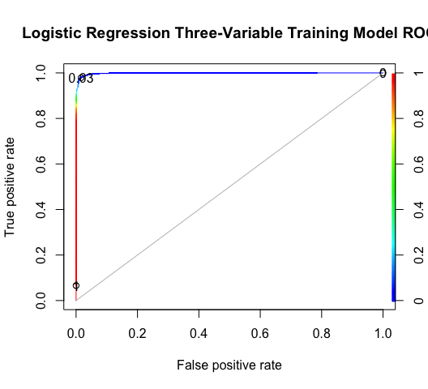

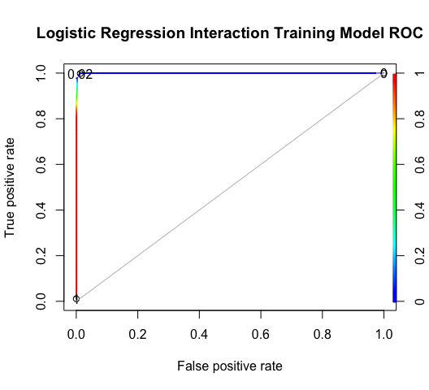

Logistic Regression Model ROCs - Training Set

The determined best probability threshold for the standard three-variable logistic regression model was 0.75, which returned an accuracy of 99.576%, FNR of 0.172%, and FPR of 8.032%. The best threshold for the interaction logistic regression model was 0.75, returning an accuracy of 99.600%, FNR of 0.267%, and FPR of 4.441%.

#### 4.2.2.2 Holdout Set Performance

Using the best thresholds determined while training the models as found in Tables 4 and 5, model performance was tested and analyzed by generating confusion matrices, ROCs and AUCs.

With a 0.75 threshold, the standard model returned a accuracy of 99.866% with a FNR of 0.072%% and FPR of 6.647%. The ROC generated appeared strong with an AUC of 0.99939. This model performed surprisingly well with the holdout data, performing better than the training data in terms of accuracy, FNR, FPR, and AUC. This indicated that the model was not over fit and has strong predictive performance.

```r
lr.cm <- cm(lr.fit, lr.thres)
lr.cm
```

```
#> Confusion Matrix and Statistics
#>
#>           Reference
#> Prediction      No     Yes
#>        No  1988267    1258
#>        Yes    1430   17668
#>
#>                Accuracy : 0.9987
#>                  95% CI : (0.9986, 0.9987)
#>     No Information Rate : 0.9906
#>     P-Value [Acc > NIR] : < 2.2e-16
#>
#>                   Kappa : 0.9286
#>
#>  Mcnemar's Test P-Value : 0.0009729
#>
#>             Sensitivity : 0.9993
#>             Specificity : 0.9335
#>          Pos Pred Value : 0.9994
#>          Neg Pred Value : 0.9251
#>              Prevalence : 0.9906
#>          Detection Rate : 0.9899
#>    Detection Prevalence : 0.9905
#>       Balanced Accuracy : 0.9664
#>
#>        'Positive' Class : No
#>
```

```r
lr.cm.i <- cm(lr.fit, lr.thres)
lr.cm.i
```

```
#> Confusion Matrix and Statistics
#>
#>           Reference
#> Prediction      No     Yes
#>        No  1988267    1258
#>        Yes    1430   17668
#>
#>                Accuracy : 0.9987
#>                  95% CI : (0.9986, 0.9987)
#>     No Information Rate : 0.9906
#>     P-Value [Acc > NIR] : < 2.2e-16
#>
#>                   Kappa : 0.9286
#>
#>  Mcnemar's Test P-Value : 0.0009729
#>
#>             Sensitivity : 0.9993
#>             Specificity : 0.9335
#>          Pos Pred Value : 0.9994
#>          Neg Pred Value : 0.9251
#>              Prevalence : 0.9906
#>          Detection Rate : 0.9899
#>    Detection Prevalence : 0.9905
#>       Balanced Accuracy : 0.9664
#>
#>        'Positive' Class : No
#>
```

```r
# ROC
lr.holdout <- holdoutperf(lr.fit,
                          "Logistic Regression Standard Model Holdout ROC",
                          lr.thres)
lr.holdout.i <- holdoutperf(lr.fit.i,
                            "Logistic Regression Interaction Model Holdout ROC",
                            lr.thres.i)

# AUC
lr.holdout
```

```
#> [1] 0.9993877
```

```r
lr.holdout.i
```

```
#> [1] 0.9997306
```

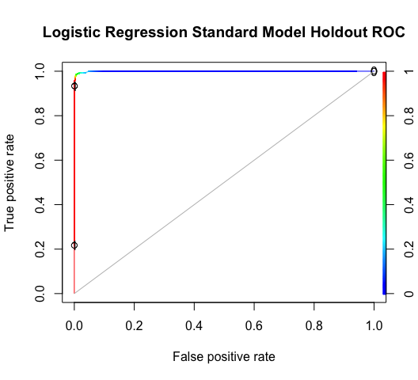

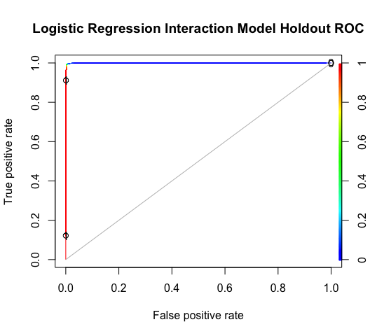

Logistic Regression Model ROCs - Holdout Set

## 4.3 LDA (Linear Discriminant Analysis)

### 4.3.1 Model Training

Linear discriminant analysis (LDA) models were generated next. The `model` function was called and the method specified as `"lda"` for both the standard and interaction models.

```r
lda.fit <- model(Bluetarp ~ ., 'lda', NULL)
lda.fit$finalModel
```

```
#> Call:
#> lda(x, grouping = y)
#>
#> Prior probabilities of groups:
#>         No        Yes
#> 0.96802707 0.03197293
#>
#> Group means:
#>          Red    Green     Blue
#> No  162.7604 152.5808 122.4993
#> Yes 169.6627 186.4149 205.0371
#>
#> Coefficients of linear discriminants:
#>               LD1
#> Red   -0.02896984
#> Green -0.02328544
#> Blue   0.06923974
```

```r
lda.fit.i <- model(Bluetarp ~ . + Green:Blue, 'lda', NULL)
lda.fit.i$finalModel
```

```
#> Call:
#> lda(x, grouping = y)
#>
#> Prior probabilities of groups:
#>         No        Yes
#> 0.96802707 0.03197293
#>
#> Group means:
#>          Red    Green     Blue Green:Blue
#> No  162.7604 152.5808 122.4993   22982.58
#> Yes 169.6627 186.4149 205.0371   40161.94
#>
#> Coefficients of linear discriminants:
#>                      LD1
#> Red        -0.0453360445
#> Green       0.0180010433
#> Blue        0.0966272667
#> Green:Blue -0.0001825495
```

### 4.3.2 Model Performance

#### 4.3.2.1 Training Set Performance

Following the creation of the LDA models, model performance was tested.

The probability threshold for the three-variable standard model was determined to be best at 0.15, returning and accuracy of 98.485%, FNR of 0.767%, and FPR of 24.174%. Although the model has a generally high accuracy and low FNR, it performed worse than the training set performed for the logistic regression model. The FPR rate was also high. An FPR of 24.174% translates to 24.174% of locations visited by aid workers were not occupied by displaced Haitians. In times of disaster, that could be a significant amount of time that is not optimized servicing individuals in need. This likely indicates this is not an optimal model type for this data set, but further analysis will be conducted to determine if the predictive performance is better with this algorithm.

The interaction model performed best with a threshold of 0.70, with an accuracy of 99.441%, FNR of 0.134%, and FPR of 13.442%. This model performed better than the standard model in all areas, though still had a relatively high FPR and performed worse than the training logistic regression models.

ROC and AUCs were generated for both models. The standard three-variable model the AUC was computed to be 0.98888 and 0.99525 for the interaction model when testing performance with the training data.

Neither of these models performed well and would not be selected over the logistic regression standard model for training set performance.

```r
lda.thres <- threshold(lda.fit)
lda.thres.i <- threshold(lda.fit.i)

# determining best threshold row for highlighting
lda.best <- lda.thres %>%
  dplyr::select("prob_threshold", "Accuracy", "FNR", "FPR", "Dist", "F1") %>%
  slice(which.max(Accuracy)) %>%
  slice(which.min(FNR))
lda.bestrow <- which(lda.thres$Accuracy == lda.best$Accuracy)

lda.best.i <- lda.thres.i %>%
  dplyr::select("prob_threshold", "Accuracy", "FNR", "FPR", "Dist", "F1") %>%
  slice(which.max(Accuracy)) %>%
  slice(which.min(FNR))
lda.bestrow.i <- which(lda.thres.i$Accuracy == lda.best.i$Accuracy)

# table of threshold values
lda.thres %>%
    dplyr::select("prob_threshold", "Accuracy", "FNR", "FPR", "Dist", "F1") %>%
    knitr::kable(digits = 5,
                 caption = "LDA Standard Model
                 Probability Threshold Table") %>%
    kableExtra::kable_styling(full_width = FALSE) %>%
    kableExtra::row_spec(row = lda.bestrow, bold = TRUE,
                         background = '#D3D3D3') %>%
    kable_styling(latex_options = "HOLD_position")
```

LDA Standard Model Probability Threshold Table

| prob_threshold | Accuracy | FNR | FPR | Dist | F1 |
| --- | --- | --- | --- | --- | --- |
| 0.05 | 0.98440 | 0.00659 | 0.28833 | 0.28840 | 0.99195 |
| 0.10 | 0.98465 | 0.00734 | 0.25796 | 0.25807 | 0.99208 |
| 0.15 | 0.98485 | 0.00767 | 0.24174 | 0.24186 | 0.99218 |
| 0.20 | 0.98460 | 0.00812 | 0.23591 | 0.23605 | 0.99204 |
| 0.25 | 0.98452 | 0.00847 | 0.22760 | 0.22775 | 0.99200 |
| 0.30 | 0.98419 | 0.00899 | 0.22235 | 0.22254 | 0.99183 |
| 0.35 | 0.98424 | 0.00927 | 0.21207 | 0.21227 | 0.99185 |
| 0.40 | 0.98416 | 0.00946 | 0.20900 | 0.20922 | 0.99181 |
| 0.45 | 0.98401 | 0.00984 | 0.20227 | 0.20251 | 0.99173 |
| 0.50 | 0.98400 | 0.01003 | 0.19664 | 0.19689 | 0.99172 |
| 0.55 | 0.98392 | 0.01029 | 0.19139 | 0.19167 | 0.99168 |
| 0.60 | 0.98368 | 0.01065 | 0.18793 | 0.18824 | 0.99155 |
| 0.65 | 0.98367 | 0.01082 | 0.18309 | 0.18341 | 0.99154 |
| 0.70 | 0.98338 | 0.01130 | 0.17765 | 0.17801 | 0.99139 |
| 0.75 | 0.98303 | 0.01184 | 0.17221 | 0.17261 | 0.99121 |
| 0.80 | 0.98290 | 0.01230 | 0.16241 | 0.16288 | 0.99114 |
| 0.85 | 0.98270 | 0.01266 | 0.15776 | 0.15827 | 0.99103 |
| 0.90 | 0.98256 | 0.01302 | 0.15134 | 0.15190 | 0.99095 |

```r
lda.thres.i %>%
    dplyr::select("prob_threshold", "Accuracy", "FNR", "FPR", "Dist", "F1") %>%
    knitr::kable(digits = 5,
                 caption = "LDA Interaction Model
                 Probability Threshold Table") %>%
    kableExtra::kable_styling(full_width = FALSE) %>%
    kableExtra::row_spec(row = lda.bestrow.i, bold = TRUE,
                         background = '#D3D3D3') %>%
    kable_styling(latex_options = "HOLD_position")
```

LDA Interaction Model Probability Threshold Table

| prob_threshold | Accuracy | FNR | FPR | Dist | F1 |
| --- | --- | --- | --- | --- | --- |
| 0.05 | 0.99317 | 0.00016 | 0.20870 | 0.20870 | 0.99648 |
| 0.10 | 0.99357 | 0.00026 | 0.19298 | 0.19298 | 0.99669 |
| 0.15 | 0.99372 | 0.00047 | 0.18200 | 0.18200 | 0.99677 |
| 0.20 | 0.99389 | 0.00060 | 0.17300 | 0.17300 | 0.99685 |
| 0.25 | 0.99391 | 0.00069 | 0.16963 | 0.16964 | 0.99686 |
| 0.30 | 0.99397 | 0.00074 | 0.16617 | 0.16617 | 0.99689 |
| 0.35 | 0.99404 | 0.00082 | 0.16152 | 0.16153 | 0.99693 |
| 0.40 | 0.99416 | 0.00089 | 0.15589 | 0.15589 | 0.99699 |
| 0.45 | 0.99420 | 0.00098 | 0.15153 | 0.15154 | 0.99701 |
| 0.50 | 0.99428 | 0.00106 | 0.14679 | 0.14679 | 0.99705 |
| 0.55 | 0.99430 | 0.00112 | 0.14421 | 0.14422 | 0.99706 |
| 0.60 | 0.99433 | 0.00118 | 0.14154 | 0.14155 | 0.99708 |
| 0.65 | 0.99435 | 0.00127 | 0.13828 | 0.13828 | 0.99709 |
| 0.70 | 0.99441 | 0.00134 | 0.13442 | 0.13443 | 0.99712 |
| 0.75 | 0.99435 | 0.00149 | 0.13165 | 0.13166 | 0.99709 |
| 0.80 | 0.99428 | 0.00165 | 0.12918 | 0.12919 | 0.99705 |
| 0.85 | 0.99430 | 0.00184 | 0.12255 | 0.12257 | 0.99706 |
| 0.90 | 0.99285 | 0.00370 | 0.11157 | 0.11166 | 0.99631 |

```r
# ROC
lda.ROC <- ROC(lda.fit, "LDA Standard Model Training ROC", lda.thres)
```

```
#> Confusion Matrix and Statistics
#>
#>           Reference
#> Prediction    No   Yes
#>        No  60875   669
#>        Yes   344  1353
#>
#>                Accuracy : 0.984
#>                  95% CI : (0.983, 0.9849)
#>     No Information Rate : 0.968
#>     P-Value [Acc > NIR] : < 2.2e-16
#>
#>                   Kappa : 0.7194
#>
#>  Mcnemar's Test P-Value : < 2.2e-16
#>
#>             Sensitivity : 0.9944
#>             Specificity : 0.6691
#>          Pos Pred Value : 0.9891
#>          Neg Pred Value : 0.7973
#>              Prevalence : 0.9680
#>          Detection Rate : 0.9626
#>    Detection Prevalence : 0.9732
#>       Balanced Accuracy : 0.8318
#>
#>        'Positive' Class : No
#>
```

```r
lda.ROC.i <- ROC(lda.fit.i, "LDA Interaction Model Training ROC", lda.thres.i)
```

```
#> Confusion Matrix and Statistics
#>
#>           Reference
#> Prediction    No   Yes
#>        No  61219   587
#>        Yes     0  1435
#>
#>                Accuracy : 0.9907
#>                  95% CI : (0.9899, 0.9915)
#>     No Information Rate : 0.968
#>     P-Value [Acc > NIR] : < 2.2e-16
#>
#>                   Kappa : 0.8256
#>
#>  Mcnemar's Test P-Value : < 2.2e-16
#>
#>             Sensitivity : 1.0000
#>             Specificity : 0.7097
#>          Pos Pred Value : 0.9905
#>          Neg Pred Value : 1.0000
#>              Prevalence : 0.9680
#>          Detection Rate : 0.9680
#>    Detection Prevalence : 0.9773
#>       Balanced Accuracy : 0.8548
#>
#>        'Positive' Class : No
#>
```

```r
# AUC
lda.ROC
```

```
#> [1] 0.9888768
```

```r
lda.ROC.i
```

```
#> [1] 0.9952491
```

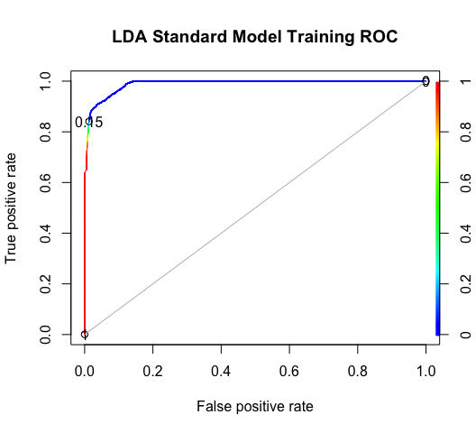

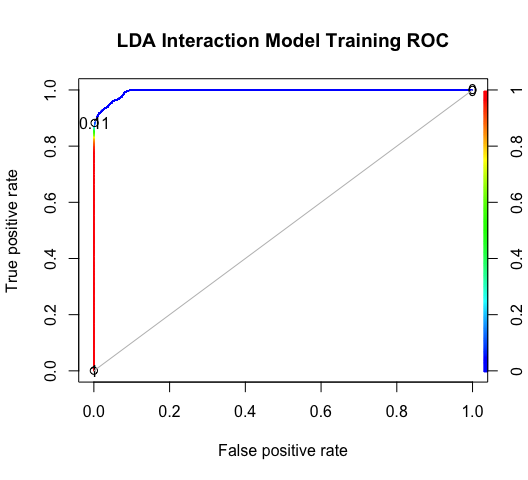

LDA Model ROCs - Training Set

#### 4.3.2.2 Holdout Set Performance

The holdout set was used to test the predictive performance of the standard and interaction LDA algorithms using the best performing thresholds from the training set.

```r
lda.cm <- cm(lda.fit, lda.thres)
lda.cm
```

```
#> Confusion Matrix and Statistics
#>
#>           Reference
#> Prediction      No     Yes
#>        No  1966903    7043
#>        Yes   22794   11883
#>
#>                Accuracy : 0.9851
#>                  95% CI : (0.985, 0.9853)
#>     No Information Rate : 0.9906
#>     P-Value [Acc > NIR] : 1
#>
#>                   Kappa : 0.4365
#>
#>  Mcnemar's Test P-Value : <2e-16
#>
#>             Sensitivity : 0.9885
#>             Specificity : 0.6279
#>          Pos Pred Value : 0.9964
#>          Neg Pred Value : 0.3427
#>              Prevalence : 0.9906
#>          Detection Rate : 0.9792
#>    Detection Prevalence : 0.9827
#>       Balanced Accuracy : 0.8082
#>
#>        'Positive' Class : No
#>
```

```r
lda.cm.i <- cm(lda.fit, lda.thres)
lda.cm.i
```

```
#> Confusion Matrix and Statistics
#>
#>           Reference
#> Prediction      No     Yes
#>        No  1966903    7043
#>        Yes   22794   11883
#>
#>                Accuracy : 0.9851
#>                  95% CI : (0.985, 0.9853)
#>     No Information Rate : 0.9906
#>     P-Value [Acc > NIR] : 1
#>
#>                   Kappa : 0.4365
#>
#>  Mcnemar's Test P-Value : <2e-16
#>
#>             Sensitivity : 0.9885
#>             Specificity : 0.6279
#>          Pos Pred Value : 0.9964
#>          Neg Pred Value : 0.3427
#>              Prevalence : 0.9906
#>          Detection Rate : 0.9792
#>    Detection Prevalence : 0.9827
#>       Balanced Accuracy : 0.8082
#>
#>        'Positive' Class : No
#>
```

```r
# ROC
lda.holdout <- holdoutperf(lda.fit, "LDA Standard Model Holdout ROC", lda.thres)
lda.holdout.i <- holdoutperf(lda.fit.i, "LDA Interaction Model Holdout ROC",
                             lda.thres.i)

# AUC
lda.holdout
```

```
#> [1] 0.9924212
```

```r
lda.holdout.i
```

```
#> [1] 0.998125
```

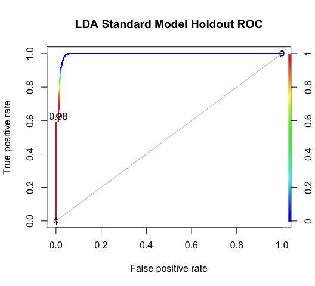

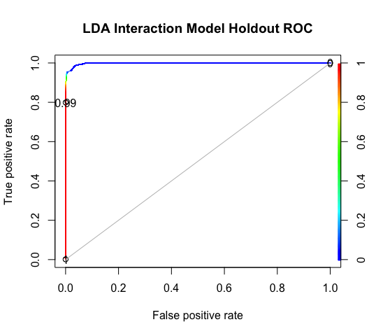

LDA Model ROCs - Holdout Set

## 4.4 QDA (Quadratic Discriminant Analysis)

### 4.4.1 Model Training

Quadratic discriminant analysis (QDA) models were created, calling the `model` function and passing `"qda"` as the method.

```r
qda.fit <- model(Bluetarp ~ ., 'qda', NULL)
qda.fit$finalModel
```

```
#> Call:
#> qda(x, grouping = y)
#>
#> Prior probabilities of groups:
#>         No        Yes
#> 0.96802707 0.03197293
#>
#> Group means:
#>          Red    Green     Blue
#> No  162.7604 152.5808 122.4993
#> Yes 169.6627 186.4149 205.0371
```

```r
qda.fit.i <- model(Bluetarp ~ . + Green:Blue, 'qda', NULL)
qda.fit.i$finalModel
```

```
#> Call:
#> qda(x, grouping = y)
#>
#> Prior probabilities of groups:
#>         No        Yes
#> 0.96802707 0.03197293
#>
#> Group means:
#>          Red    Green     Blue Green:Blue
#> No  162.7604 152.5808 122.4993   22982.58
#> Yes 169.6627 186.4149 205.0371   40161.94
```

### 4.4.2 Model Performance

#### 4.4.2.1 Training Set Performance

Model training performance was conducted on both the standard and interaction models generated with QDA. The best probability threshold was calculated to 0.75 for the standard model and 0.05 for the interaction model. The standard model’s accuracy at threshold 0.75 was 99.478% with an FNR of 0.085%, and FPR of 13.759%. The AUC was determined to be 0.99822.

The interaction model returned an accuracy of 99.469% with a 0.061% FNR, and 14.738% FPR when at a 0.05 probability threshold. The AUC was 0.99709.

Both of these models performed fairly well with the training data than the LDA models. The standard model performed better than the interaction model, but neither performed as well as the logistic regression models with training data and both returned high FPR suggesting these algorithms may also not be the best suited for the training data.

```r
qda.thres <- threshold(qda.fit)
qda.thres.i <- threshold(qda.fit.i)

# determining best threshold row for highlighting
qda.best <- qda.thres %>%
  dplyr::select("prob_threshold", "Accuracy", "FNR", "FPR", "Dist", "F1") %>%
  slice(which.max(Accuracy)) %>%
  slice(which.min(FNR))
qda.bestrow <- which(qda.thres$Accuracy == qda.best$Accuracy)

qda.best.i <- qda.thres.i %>%
  dplyr::select("prob_threshold", "Accuracy", "FNR", "FPR", "Dist", "F1") %>%
  slice(which.max(Accuracy)) %>%
  slice(which.min(FNR))
qda.bestrow.i <- which(qda.thres.i$Accuracy == qda.best.i$Accuracy)

# table of threshold values
qda.thres %>%
    dplyr::select("prob_threshold", "Accuracy", "FNR", "FPR", "Dist", "F1") %>%
    knitr::kable(digits = 5,
                 caption = "QDA Standard Model
                 Probability Threshold Table") %>%
    kableExtra::kable_styling(full_width = FALSE) %>%
    kableExtra::row_spec(row = qda.bestrow, bold = TRUE,
                         background = '#D3D3D3') %>%
    kable_styling(latex_options = "HOLD_position")
```

QDA Standard Model Probability Threshold Table

| prob_threshold | Accuracy | FNR | FPR | Dist | F1 |
| --- | --- | --- | --- | --- | --- |
| 0.05 | 0.99178 | 0.00000 | 0.25697 | 0.25697 | 0.99577 |
| 0.10 | 0.99272 | 0.00002 | 0.22690 | 0.22690 | 0.99626 |
| 0.15 | 0.99324 | 0.00005 | 0.20989 | 0.20989 | 0.99652 |
| 0.20 | 0.99352 | 0.00008 | 0.20020 | 0.20020 | 0.99666 |
| 0.25 | 0.99375 | 0.00011 | 0.19199 | 0.19199 | 0.99678 |
| 0.30 | 0.99398 | 0.00014 | 0.18408 | 0.18408 | 0.99690 |
| 0.35 | 0.99409 | 0.00019 | 0.17923 | 0.17923 | 0.99695 |
| 0.40 | 0.99424 | 0.00024 | 0.17270 | 0.17270 | 0.99704 |
| 0.45 | 0.99435 | 0.00028 | 0.16815 | 0.16815 | 0.99709 |
| 0.50 | 0.99450 | 0.00032 | 0.16222 | 0.16222 | 0.99717 |
| 0.55 | 0.99462 | 0.00037 | 0.15717 | 0.15717 | 0.99723 |
| 0.60 | 0.99469 | 0.00043 | 0.15302 | 0.15302 | 0.99726 |
| 0.65 | 0.99467 | 0.00057 | 0.14936 | 0.14936 | 0.99725 |
| 0.70 | 0.99471 | 0.00071 | 0.14392 | 0.14392 | 0.99727 |
| 0.75 | 0.99478 | 0.00085 | 0.13759 | 0.13759 | 0.99731 |
| 0.80 | 0.99384 | 0.00208 | 0.12948 | 0.12951 | 0.99682 |
| 0.85 | 0.99276 | 0.00348 | 0.12087 | 0.12095 | 0.99626 |
| 0.90 | 0.99011 | 0.00694 | 0.09941 | 0.09966 | 0.99488 |

```r
qda.thres.i %>%
    dplyr::select("prob_threshold", "Accuracy", "FNR", "FPR", "Dist", "F1") %>%
    knitr::kable(digits = 5,
                 caption = "QDA Interaction Model
                 Probability Threshold Table") %>%
    kableExtra::kable_styling(full_width = FALSE) %>%
    kableExtra::row_spec(row = qda.bestrow.i, bold = TRUE,
                         background = '#D3D3D3') %>%
    kable_styling(latex_options = "HOLD_position")
```

QDA Interaction Model Probability Threshold Table

| prob_threshold | Accuracy | FNR | FPR | Dist | F1 |
| --- | --- | --- | --- | --- | --- |
| 0.05 | 0.99469 | 0.00061 | 0.14738 | 0.14738 | 0.99726 |
| 0.10 | 0.99395 | 0.00182 | 0.13393 | 0.13395 | 0.99688 |
| 0.15 | 0.99261 | 0.00353 | 0.12413 | 0.12421 | 0.99618 |
| 0.20 | 0.99119 | 0.00528 | 0.11553 | 0.11567 | 0.99545 |
| 0.25 | 0.99016 | 0.00661 | 0.10762 | 0.10782 | 0.99491 |
| 0.30 | 0.98993 | 0.00697 | 0.10396 | 0.10419 | 0.99479 |
| 0.35 | 0.98969 | 0.00737 | 0.09951 | 0.09978 | 0.99466 |
| 0.40 | 0.98951 | 0.00767 | 0.09604 | 0.09635 | 0.99457 |
| 0.45 | 0.98929 | 0.00802 | 0.09238 | 0.09273 | 0.99445 |
| 0.50 | 0.98905 | 0.00837 | 0.08882 | 0.08922 | 0.99433 |
| 0.55 | 0.98878 | 0.00877 | 0.08546 | 0.08591 | 0.99419 |
| 0.60 | 0.98842 | 0.00922 | 0.08309 | 0.08360 | 0.99400 |
| 0.65 | 0.98795 | 0.00981 | 0.07992 | 0.08053 | 0.99375 |
| 0.70 | 0.98746 | 0.01039 | 0.07755 | 0.07825 | 0.99350 |
| 0.75 | 0.98687 | 0.01109 | 0.07507 | 0.07590 | 0.99319 |
| 0.80 | 0.98564 | 0.01251 | 0.07033 | 0.07145 | 0.99254 |
| 0.85 | 0.98386 | 0.01456 | 0.06400 | 0.06567 | 0.99161 |
| 0.90 | 0.98037 | 0.01846 | 0.05500 | 0.05809 | 0.98978 |

```r
#ROC
qda.ROC <- ROC(qda.fit, "QDA Standard Model Training ROC", qda.thres)
```

```
#> Confusion Matrix and Statistics
#>
#>           Reference
#> Prediction    No   Yes
#>        No  61219   726
#>        Yes     0  1296
#>
#>                Accuracy : 0.9885
#>                  95% CI : (0.9877, 0.9893)
#>     No Information Rate : 0.968
#>     P-Value [Acc > NIR] : < 2.2e-16
#>
#>                   Kappa : 0.7756
#>
#>  Mcnemar's Test P-Value : < 2.2e-16
#>
#>             Sensitivity : 1.0000
#>             Specificity : 0.6409
#>          Pos Pred Value : 0.9883
#>          Neg Pred Value : 1.0000
#>              Prevalence : 0.9680
#>          Detection Rate : 0.9680
#>    Detection Prevalence : 0.9795
#>       Balanced Accuracy : 0.8205
#>
#>        'Positive' Class : No
#>
```

```r
qda.ROC.i <-ROC(qda.fit.i, "QDA Interaction Model Training ROC", qda.thres.i)
```

```
#> Confusion Matrix and Statistics
#>
#>           Reference
#> Prediction    No   Yes
#>        No  61210   382
#>        Yes     9  1640
#>
#>                Accuracy : 0.9938
#>                  95% CI : (0.9932, 0.9944)
#>     No Information Rate : 0.968
#>     P-Value [Acc > NIR] : < 2.2e-16
#>
#>                   Kappa : 0.8903
#>
#>  Mcnemar's Test P-Value : < 2.2e-16
#>
#>             Sensitivity : 0.9999
#>             Specificity : 0.8111
#>          Pos Pred Value : 0.9938
#>          Neg Pred Value : 0.9945
#>              Prevalence : 0.9680
#>          Detection Rate : 0.9679
#>    Detection Prevalence : 0.9739
#>       Balanced Accuracy : 0.9055
#>
#>        'Positive' Class : No
#>
```

```r
#AUC
qda.ROC
```

```
#> [1] 0.9982175
```

```r
qda.ROC.i
```

```
#> [1] 0.9970854
```

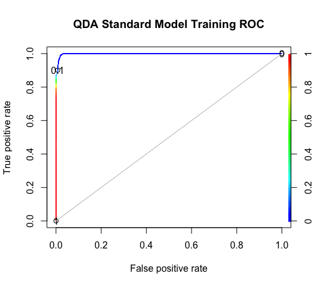

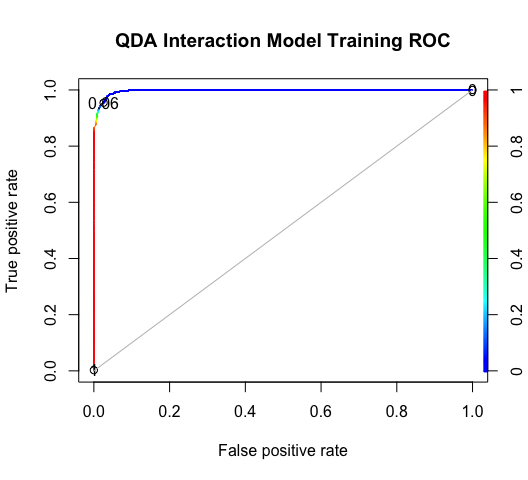

QDA Model ROCs - Training Set